# CS 1675 Final Project

Part v Interpretation and optimization

Teoh Zhixiang

## Load packages and data

```r
library(tidyverse)
library(caret)
df <- readr::read_rds("df.rds")
step_2_b_df <- readr::read_rds("step_2_b_df.rds")
step_2_a_df <- readr::read_rds("step_2_a_df.rds")
iii_models <- readr::read_rds("iii_models.rds")
iv_models <- readr::read_rds("iv_models.rds")
```

## Overview

1. Exploration
2. Regression models
3. Binary classification option b
4. Binary classification option a
5. **Interpretation and optimization**

This R Markdown file tackles part v, specifically evaluating the results from parts iii and iv, identifying the most important variables associated with the best performing models, visualizing the probability of failure as a function of the identified most important variables, and determining, based on visualizations, the input settings associated with minimizing the failure probability.

## Evaluating `response_1` as a feature

### ROC

First compare the results between the two best performing models from parts iii and iv, based on AUC.

```r
results <- resamples(list(iii_rf = iii_models$iii_rf,
                          iii_xgb = iii_models$iii_xgb,
                          iv_rf = iv_models$iv_rf,
                          iv_xgb = iv_models$iv_xgb))
```

Then we visually compare the performance metrics.

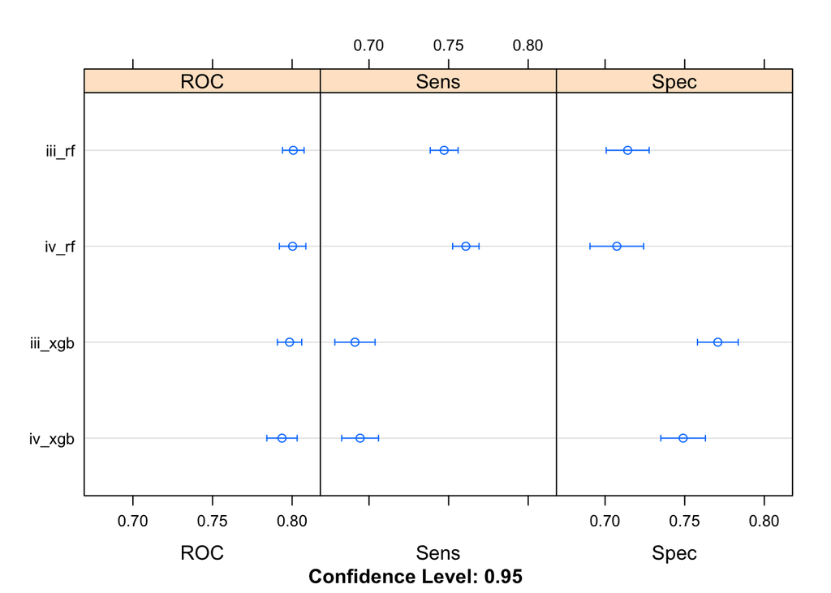

```r
dotplot(results)
```

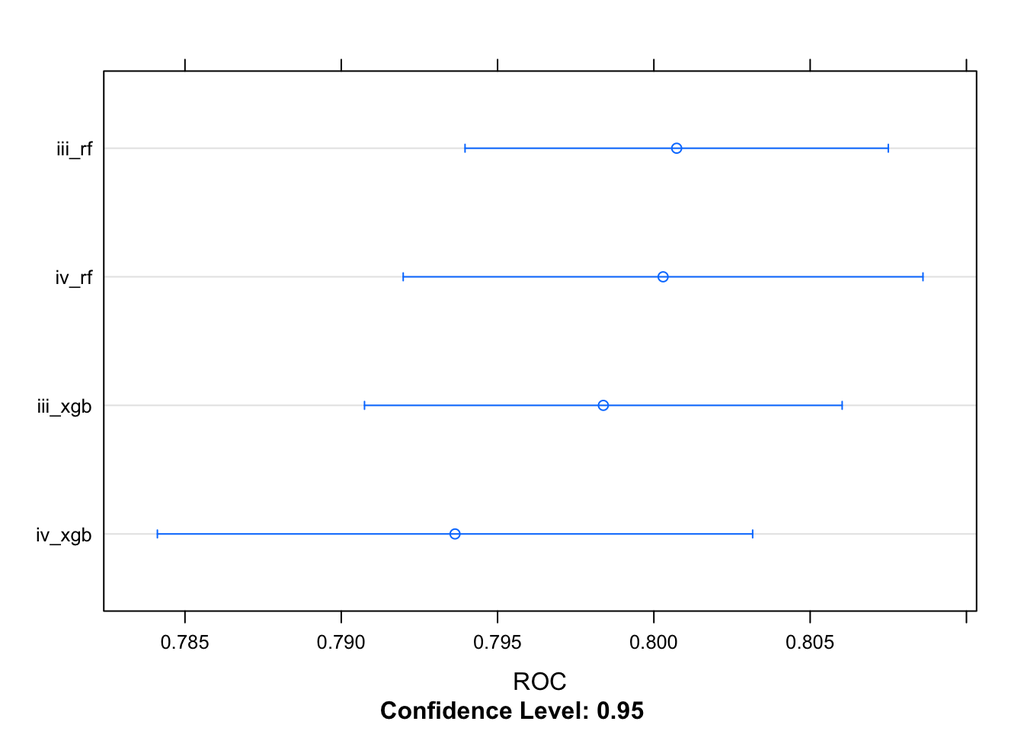

```r
dotplot(results, metric = "ROC")
```

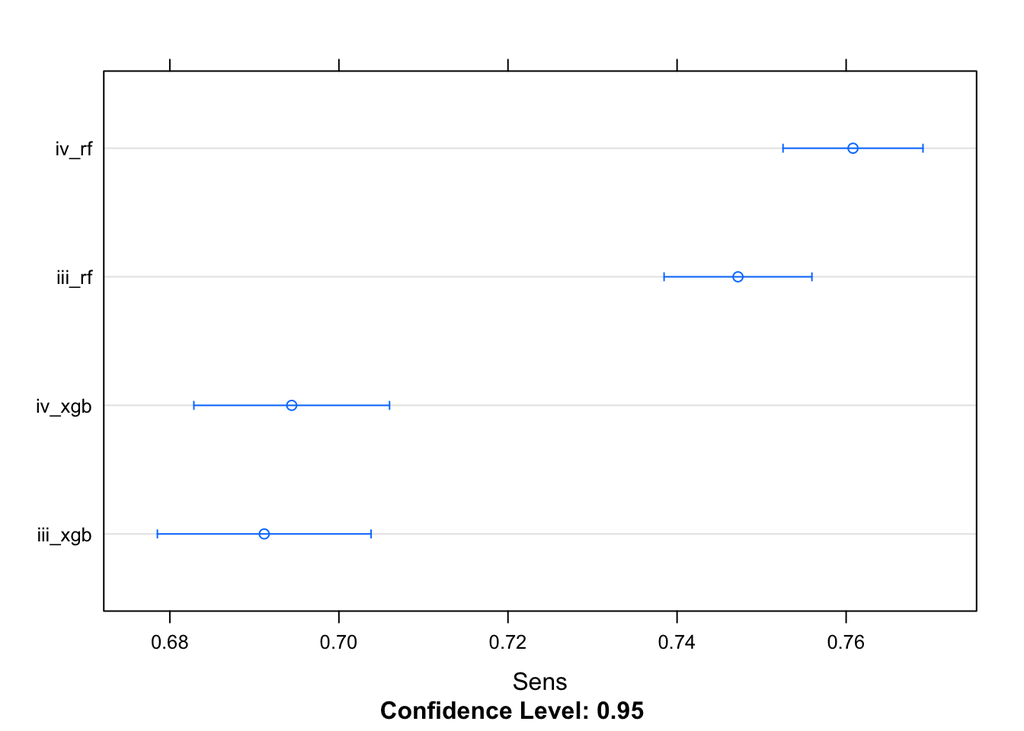

```r
dotplot(results, metric = "Sens")
```

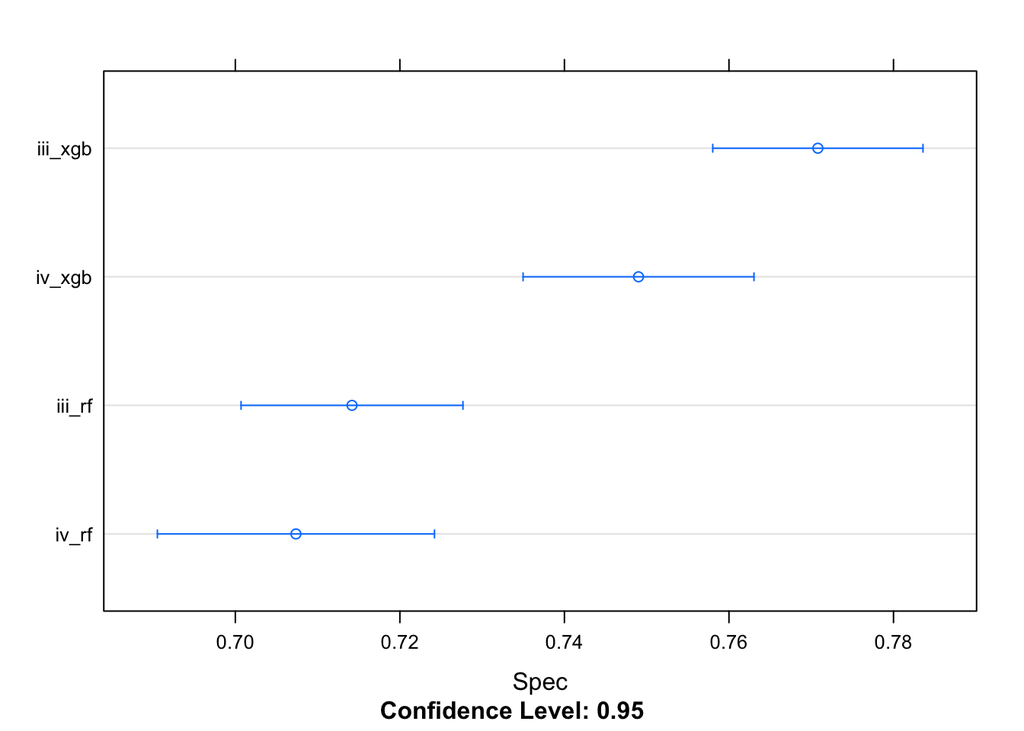

```r
dotplot(results, metric = "Spec")
```

Based on AUC, the models including `response_1` as a feature yield better performance in predicting `outcome_2`, as observable from the higher `ROC` values for both `iii_rf` and `iii_xgb`.

### Accuracy

```r
calc_accuracy <- function(model) {
  cf <- confusionMatrix.train(model)

  return( (cf$table[1,1] + cf$table[2,2]) / 100 )
}

models <- list(iii_rf = iii_models$iii_rf,
               iii_xgb = iii_models$iii_xgb,
               iv_rf = iv_models$iv_rf,
               iv_xgb = iv_models$iv_xgb)

accuracy_results <- purrr::map_dbl(models, calc_accuracy)

accuracy_results %>% sort(decreasing = TRUE)
```

```
##     iv_rf   iii_xgb    iii_rf    iv_xgb
## 0.7335320 0.7318430 0.7303527 0.7223050
```

## Variable importance

### Models with `response_1` as a feature

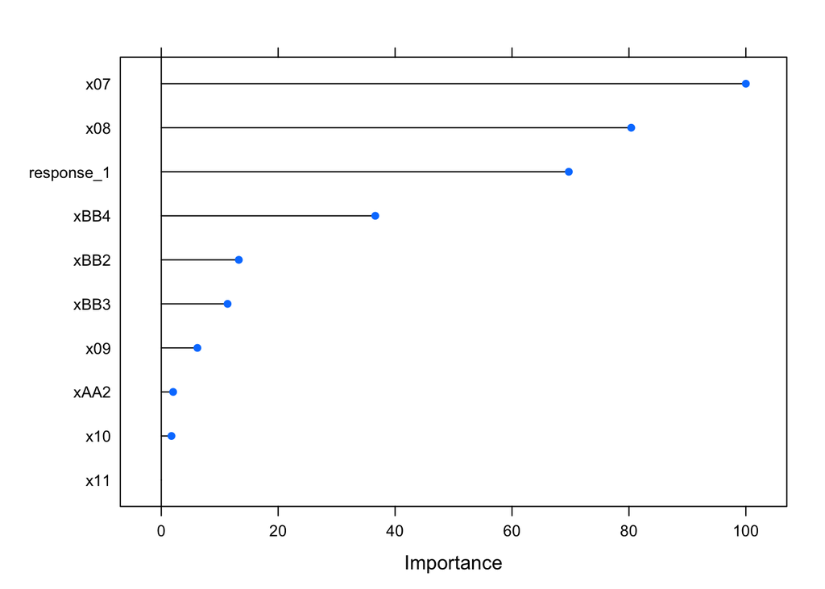

```r
plot(varImp(iii_models$iii_rf))
```

Plot variable importance based on `xgb` model.

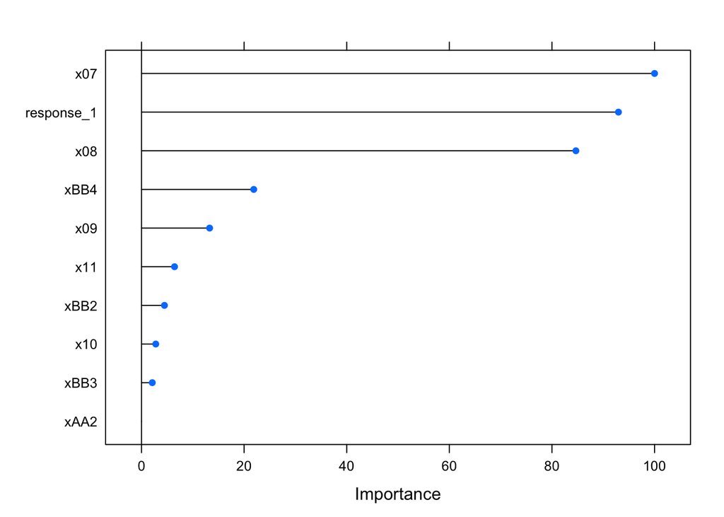

```r
plot(varImp(iii_models$iii_xgb))
```

`x07`, `x08` and `response_1` seem to be the three most important inputs.

### Models without `response_1` as a feature

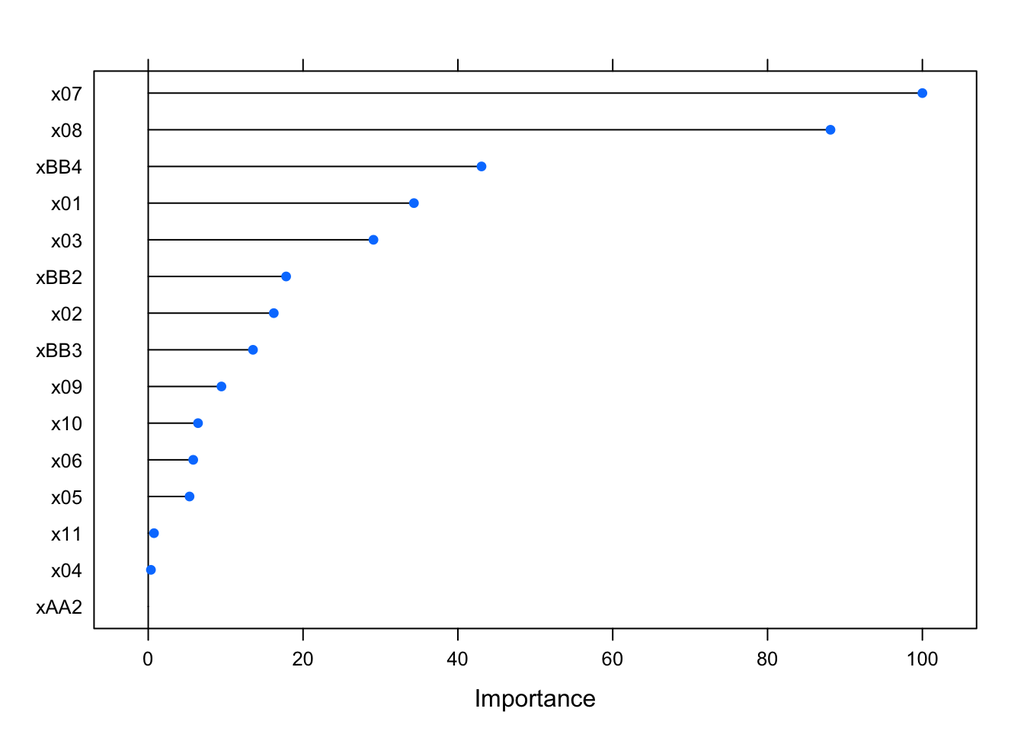

```r
plot(varImp(iv_models$iv_rf))
```

Plot variable importance based on `xgb` model.

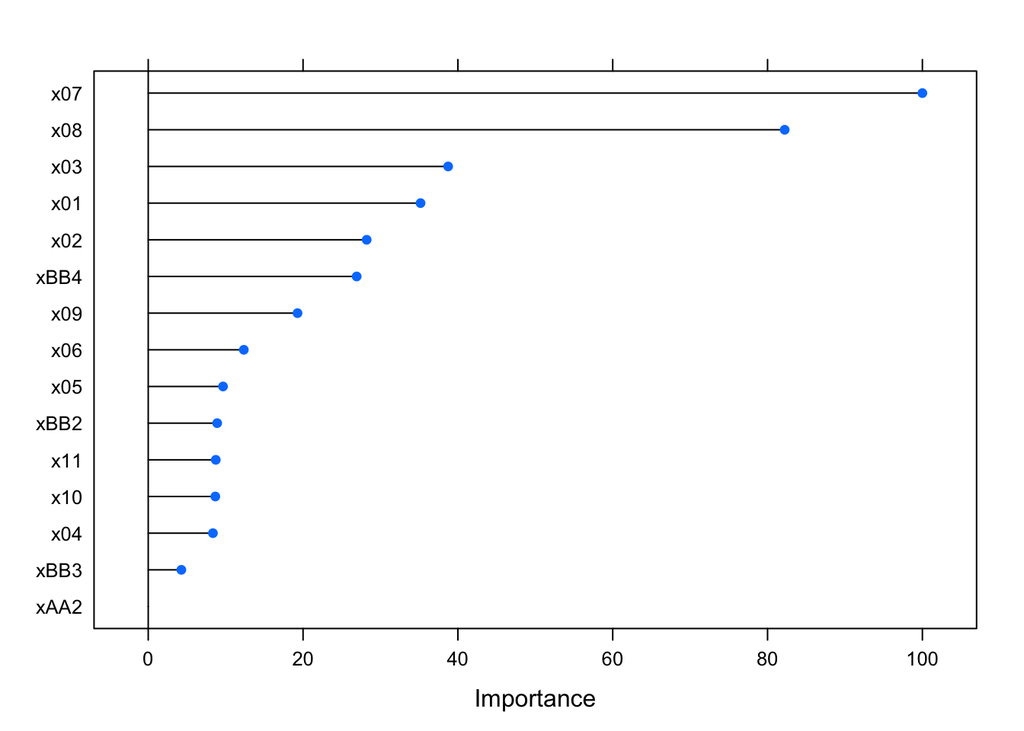

```r
plot(varImp(iv_models$iv_xgb))
```

`x07` and `x08` seem to be the two most important inputs.

### Summary

In general, inputs `x07`, `x08` seem to be the most importance variables. `response_1` is also an important variable for the models including `response_1` as one of the features.

## Partial dependence - visualizing `Fail` probability against most important variables

```r
library(pdp)
# Custom prediction function wrapper
# pdp_pred <- function(object, newdata)  {
#   results <- mean(as.vector(predict(object, newdata)))
#   return(results)
# }

# Compute partial dependence values
pd_values_x07 <- partial(
  iii_models$iii_rf,
  train = step_2_b_df,
  pred.var = "x07"
)

head(pd_values_x07)  # take a peak
```

```
##        x07       yhat
## 1 140.3138 0.09749985
## 2 140.4843 0.09718262
## 3 140.6547 0.08530345
## 4 140.8251 0.08752993
## 5 140.9955 0.18662981
## 6 141.1660 0.20324699
```

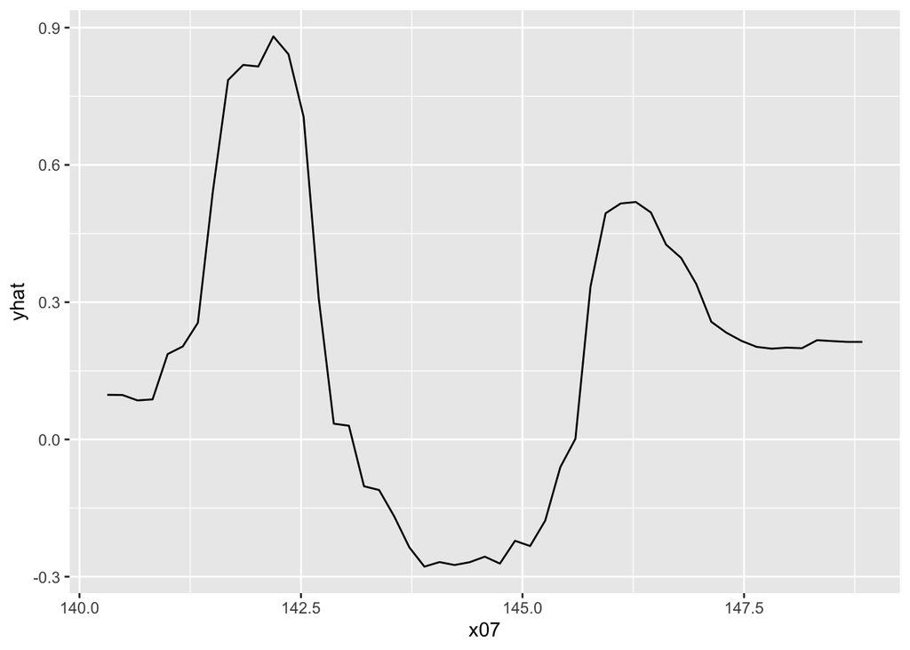

```r
# Partial dependence plot
autoplot(pd_values_x07)
```

```r
# Compute partial dependence values
pd_values_x08 <- partial(
  iii_models$iii_rf,
  train = step_2_b_df,
  pred.var = "x08"
)

head(pd_values_x08)  # take a peak
```

```
##        x08      yhat
## 1 74.03725 0.1086069
## 2 74.21489 0.1235168
## 3 74.39253 0.1235168
## 4 74.57017 0.1264428
## 5 74.74781 0.1307514
## 6 74.92545 0.1931101
```

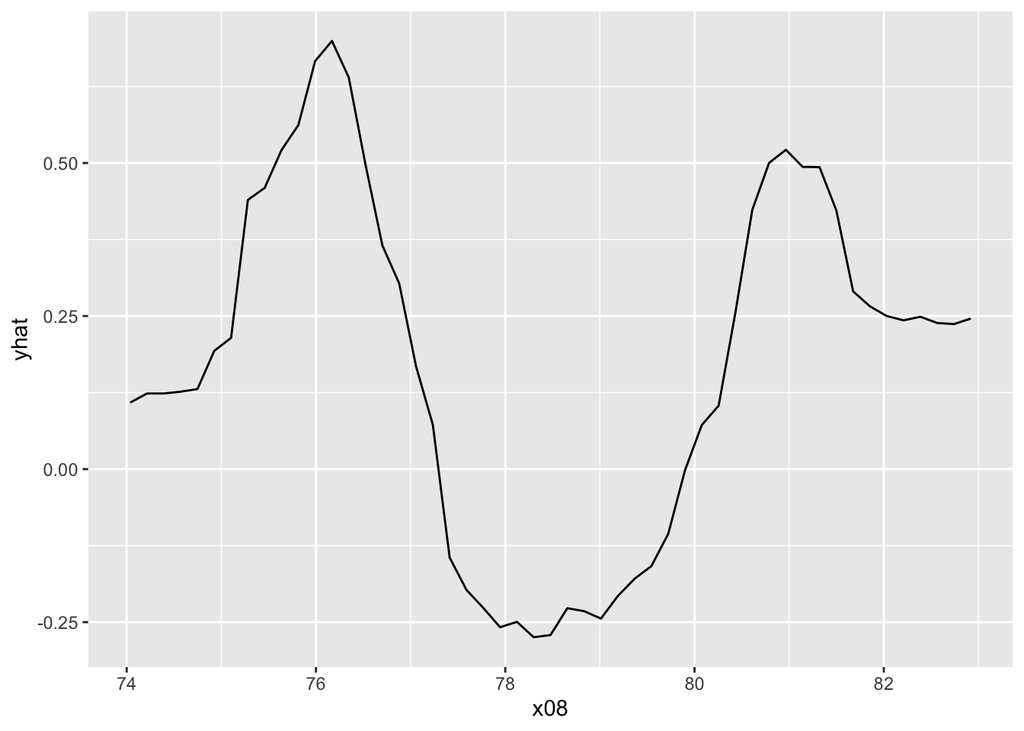

```r
# Partial dependence plot
autoplot(pd_values_x08)
```

## Input settings to minimize `Fail` probability

Find the optimal settings for `x07` and `x08` to minimize `Fail` probability, from partial dependence calculations.

```r
pd_values_x07 %>% as_tibble() %>% filter(pd_values_x07$yhat == min(pd_values_x07$yhat)) %>% select(x07)
```

```
## # A tibble: 1 x 1
##     x07
##   <dbl>
## 1  144.
```

```r
pd_values_x08 %>% as_tibble() %>% filter(pd_values_x08$yhat == min(pd_values_x08$yhat)) %>% select(x08)
```

```
## # A tibble: 1 x 1
##     x08
##   <dbl>
## 1  78.3
```